# In class R Practice Sampling and Simulating Probability

March 13, 2025

Note: link to [special vectors and sampling](https://mphitchman.com/math340/sampling-in-R.html) tutorial.

## Part I: Special vectors

**1.** Define a vector `a` to be the set of integers: 1, 2, 3, $\ldots$, 10000.

```r
a <- 1:10000
```

**2.** Define a vector `b` to be the set of integers: 5, 10, 15, $\ldots$, 10000.

```r
b <- seq(5,10000,5)
```

**3.** Define a vector `c` to be the set of real numbers: 0, 0.1, 0.2, 0.3, $\ldots$, 2.0.

```r
c <- seq(0,2,0.1)
```

**4.** Define a vector `class` to be the students in this class. Here, I’ll do it:

```r
class <- c("Sasha","Aidan","Annika","Santi","Eli","Jadyn","Shawn","Carter",
           "Ryder","Nick","Lisa","Alexis","Chase","Emerson","Miki")
```

## Part II: Sampling

**5.** Use the `sample()` command to define a vector `rolls` that records 10000 rolls of a fair 20 sided die. Then make a quick barplot of your data, using `barplot(table(rolls))` to see whether the die appears to be fair. That is, is the sample fairly uniform (meaning each number comes up about the same number of times)?

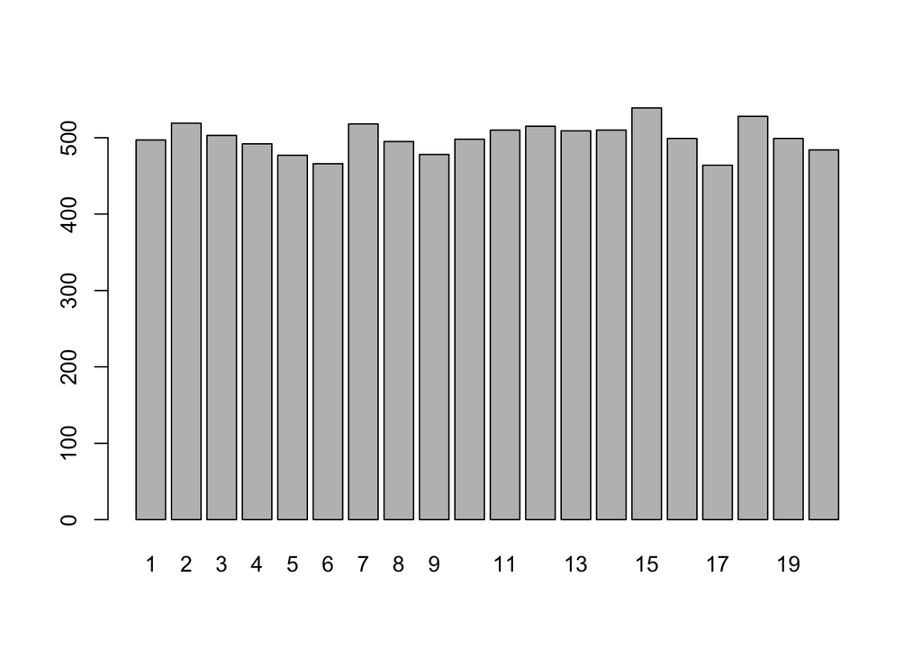

```r
rolls <- sample(1:20,10000,replace=TRUE)
barplot(table(rolls))
```

Yep, looks to me fairly uniform - any differences explained by randomness in sampling.

**6.** Load the tidyverse into your session. Then use the `sample()` command to choose a random sample of 10 distinct names from the starwars data. Is Yoda in your sample?

```r
library(tidyverse)
sample(starwars$name,10)
```

```
##  [1] "Luke Skywalker"  "Wat Tambor"      "Chewbacca"       "Roos Tarpals"
##  [5] "Adi Gallia"      "Dexter Jettster" "Luminara Unduli" "Eeth Koth"
##  [9] "Padmé Amidala"   "R2-D2"
```

**7.** Use the `sample()` command to randomly pick 4 students in `class` to be in a lab group.

```r
sample(class,4)
```

```
## [1] "Jadyn"   "Eli"     "Emerson" "Sasha"
```

**8.** Use the `sample()` command to record in the vector `skee` a simulation of 1000 shots of skee ball, assuming the following probability distribution for each shot:
$$\begin{array}{c|c|c|c|c|c|c}
x & 0 & 10 & 20 & 30 & 40 & 50\\ \hline
p(x) & .1 & .2 & .1 & .1 & .4 & .1
\end{array}$$
Then make a barplot of the results. Does it reflect the probability distribution?

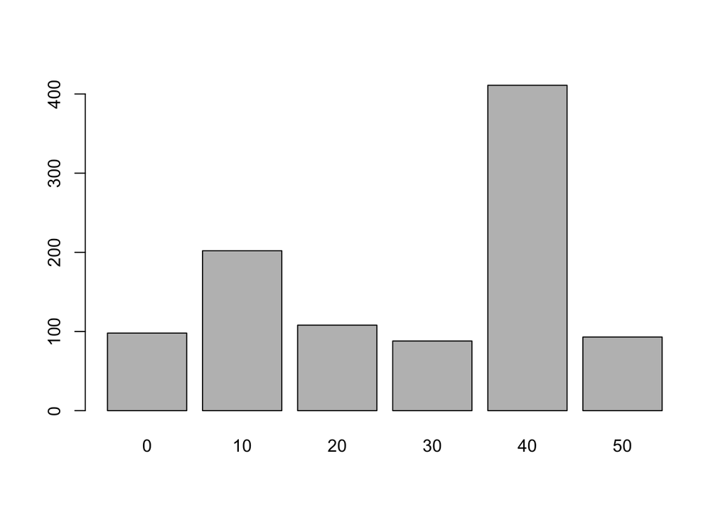

```r
x <- seq(0,50,10) # different possible scores
px <- c(.1,.2,.1,.1,.4,.1) #corresponding probabilities
skee <- sample(x,1000,replace=TRUE,prob=px)
barplot(table(skee))
```

Yep, looks like it reflects the probability distribution, 40 twice as likely as 10, and 4 times as likely as the others.

**9.** Use `rnorm()` to define a vector `AVG` to be a random sample of size 500 from a normal distribution with mean $\mu = 0.275$ and standard deviation $\sigma = 0.009$. Then make a quick histogram of your data, using `hist(AVG)`. Is most of your distribution within 3$\sigma$ of $\mu$?

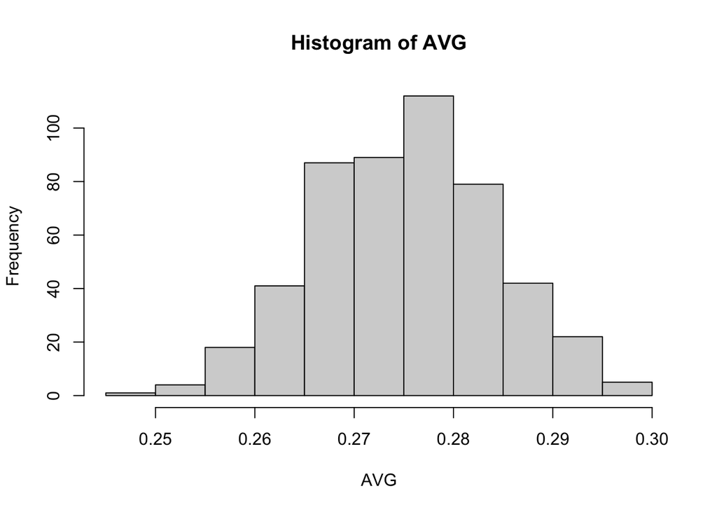

```r
AVG <- rnorm(500,0.275,0.009)
hist(AVG)
```

Yup, most of the distribtuion is within 3 st. deviations of the mean, which, in this case, is the range .248 to .302.

**10.** Use `rbinom()` to define a vector that records how many 3-point shots a player makes each night in a 40 game season, assuming she attempts 9 3-point shots per game,and the probability she makes any single shot is 0.35. Then determine how many 3-point shots she made for the season and calculate her actual 3-point shooting percentage for the simulated season. Is it 35% on the nose? Close to 35%?

```r
v <- rbinom(40,9,.35)
sum(v)
```

```
## [1] 128
```

```r
sum(v)/(9*40)
```

```
## [1] 0.3555556
```

Nope, not 35% right on the nose, but close!

## Part III: `for` loops

**11.** You have two fair 10-sided dice (die A and die B). Don’t ask what they look like, but they are numbered 0-9, not 1-10. Write a `for` loop to record the results of repeating the following game 10000 times: roll each die once and record the value that is 10*A + B in a vector called `results`. (After the loop ends, `results` should have 10000 values.) Then report what the mean and standard deviation of the `results` vector. Also make a histogram of the `results` to see what the shape looks like.

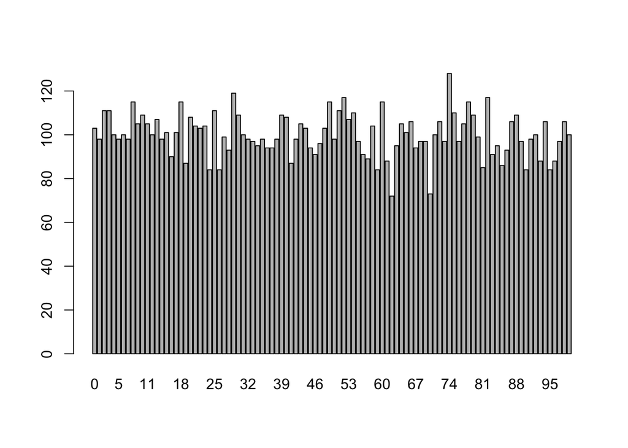

```r
results <- c()

for (i in 1:10000){
  A = sample(0:9,1,replace=FALSE)
  B = sample(0:9,1,replace=FALSE)
  results[i] <- 10*A + B
}

barplot(table(results))
```

Looks fairly uniform! Wait a minute, are we just picking a random integer between 0 and 99?

The mean is `mean(results)` = 49.04 and the standard deviation is `sd(results)` = 28.89.

## Part IV: creating functions

```r
skeeball_game <- function(px = c(.1,.2,.1,.1,.4,.1), n = 6){
    #px = probability distribution for X
    #n = number of balls
    score <- sum(sample(seq(0,50,10),
                        n,
                        replace=T,
                        prob=px))
    return(score)
}
```

**12**. Write a `for` loop that plays 10000 games between myself (*mph*) and my brother Dave and records each of our scores in each game as well as how many times each of us won. When the dust settles, who won more often? How many times did we tie?

```r
# results vectors for my scores and Dave's
mph = c()
dave = c()

# counters for my wins and Dave's
mph_wins = 0
dave_wins = 0

for (i in 1:10000){
  mph[i] = skeeball_game(px = c(.1,.2,.1,.1,.4,.1),n=6)
  dave[i] = skeeball_game(px = c(.1,.2,.2,.1,.1,.3),n=6)

  if (mph[i] > dave[i]){mph_wins = mph_wins + 1}
  if (mph[i] < dave[i]){dave_wins = dave_wins + 1}
}
cat(mph_wins,dave_wins)
```

```
## 4663 4645
```

I won 4663 times; Dave won 4645 times, and so we must have tied 692 times.

**13.** Write a function called `chuck_a_luck` that takes one input variable `k`, rolls three fair 6-sided dice and returns how many times the value `k` appears on the three dice. For instance, if the input variable is `k = 3`, and you roll 4, 4, and 6, the function should return 0.

```r
chuck_a_luck <- function(k){
  x = sample(1:6,3,replace=TRUE)
  return(sum(x == k))
}
```

**14.** Use your `chuck_a_luck` function to play 10000 times with the number 5, and record in a vector the number of 5s rolled in each attempt. Then use this vector to estimate a probability distribution for $X$, the number of times we roll 5 in a game of chuck-a-luck.

```r
results <- c()
for (i in 1:10000){
  results[i] <- chuck_a_luck(5)
}
table(results)/10000
```

```
## results
##      0      1      2      3
## 0.5838 0.3448 0.0679 0.0035
```